# GroupTrack<sup>OG</sup> — User Manual

**When to use it.** A trip near a state line, or one area of a big state; and at least once a season for the areas you ride.

Step by step

1. Map › **Import trails by area**. Draw a rectangle round the area (**CLEAR** to draw again).
2. The list shows every state and source your box touches. A state you already imported whole starts unticked. **Untick anything you do not want** — for example a state the box only clips.
3. **START**. Each source is processed in turn; when it finishes it shows what each added.

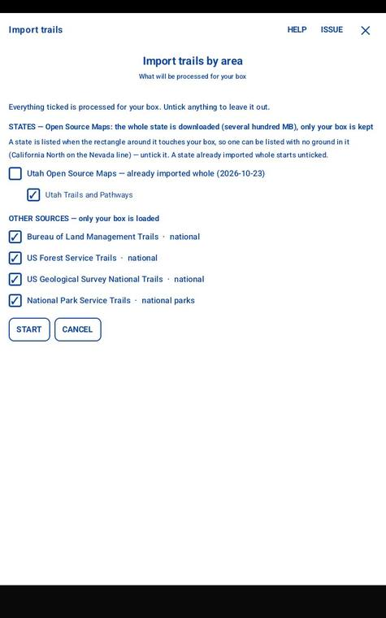

Summary of data to be processed

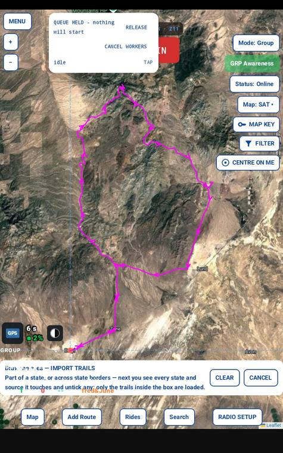

Import trails by area

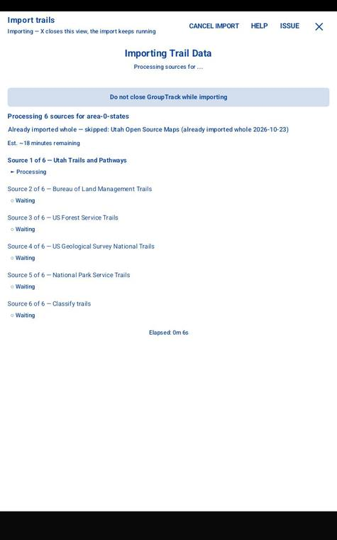

Import trails by area processing

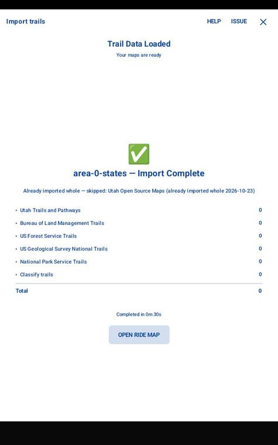

Import trails by area completed

**Import trails by state**

Overview

**What it does.** Loads every mapped trail in a state from the public sources GroupTrack<sup>OG</sup> uses — US Forest Service, BLM, National Park Service, USGS, the state's own trail data (Utah, Arizona, Colorado) and OpenStreetMap — with who owns the land each trail crosses.

**How you use it.** Pick the state, check the sources, tap IMPORT. About 10 minutes on Wi-Fi for Utah. Run it again at least once a season — the agencies and OpenStreetMap add and define new trails all the time.

**What it means to you.** The trails you can ride, on public land, in front of you with no signal — and the ground your routes are built from. You can add more: your tracks create trail segments where you ride, and Import files brings in local trail maps (KML, KMZ, GeoJSON, GPX).

**When to use it.** Your home state at first start; any state before you ride there; and at least once a season to pick up newly defined trails.

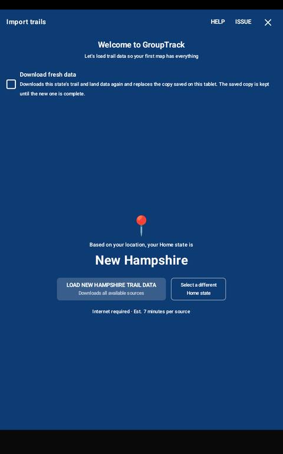

State trails download

Step by step

1. Map › **Import trails by state**. GroupTrack<sup>OG</sup> offers your home state from your location; **Select a different Home state** to choose another.
2. Tap **LOAD … TRAIL DATA**. Internet is needed; it takes several minutes per source.
3. Each source is processed in turn. **Keep GroupTrack<sup>OG</sup> open while importing**; ✕ closes the view and the import keeps running.
4. When it finishes, each source shows how many trails it added (and how many you already had). **OPEN RIDE MAP**.

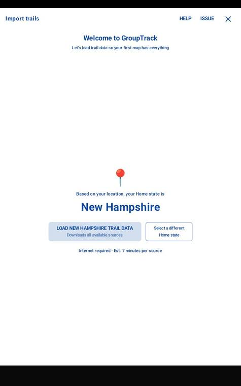

Import trails by state

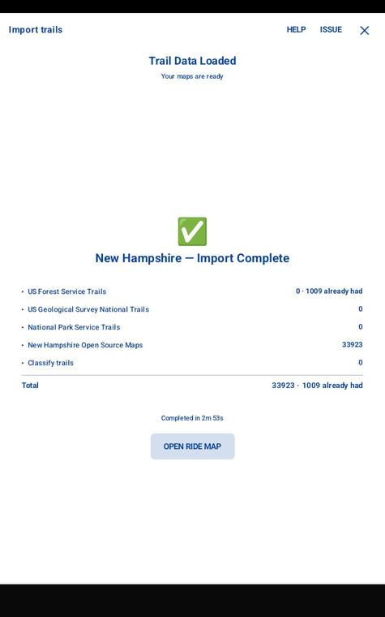

State import trails summary

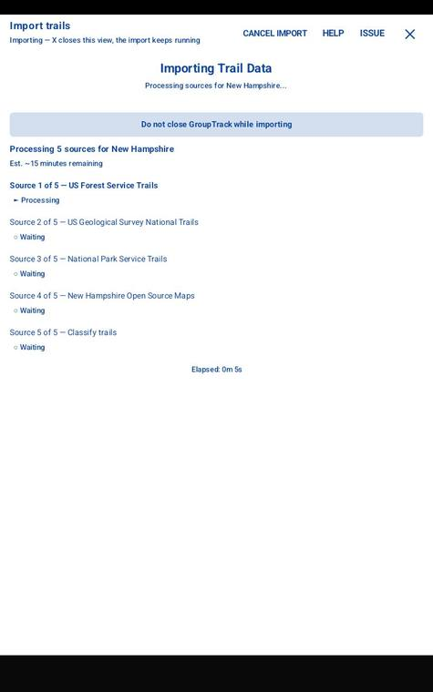

Importing state trails processing

**Map source**

Overview

**What it does.** Shows the map GroupTrack<sup>OG</sup> uses — one vector map built from OpenStreetMap open data, with the shape of the ground from public elevation data — and the credits each source requires.

**How you use it.** Open it to read where the map comes from. There is nothing to choose: GroupTrack<sup>OG</sup> has one map.

**What it means to you.** The map on your tablet is licensed to be kept and used with no signal, and its sources are credited as copyright and the source licences require.

**When to use it.** Someone asks where the map comes from, or why it looks different from Google or Esri.

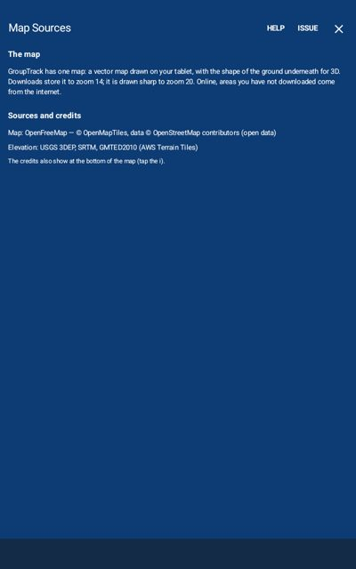

New map source panel

Step by step

Map › **Map source** (or Settings › Change Map Sources) shows the map in use.

**Refresh maps**

Overview

**What it does.** Downloads all your maps again — map images and data — and brings them current, in one process.

**How you use it.** Confirm; the download queue shows progress.

**What it means to you.** Every map on your tablet is up to date in one step.

**When to use it.** Your maps are old, or show gaps.

Step by step

1. Map › **Refresh maps**.
2. GroupTrack adds up the tiles you actually hold, zoom level by zoom level, and how many jobs it makes. Only those are downloaded again — ground with no tiles is never requested.
3. **PROCEED TO COPY**. The jobs run in the download queue, which keeps its time estimate up to date.

Your maps keep working while it runs: each tile is replaced in place, so nothing is removed first.

[figure not shown]

Refresh maps by source

**Remove maps by area**

Overview

**What it does.** Deletes the downloaded maps — map and ground shape — inside a box you draw.

**How you use it.** Draw the box, confirm. You can download the area again any time.

**What it means to you.** You keep space for the areas you ride often. A holiday ride three states away probably does not need its maps kept. Maps take little space now, so use this only as needed.

**When to use it.** After a trip to an area you will not ride again soon, or when the tablet is short of space.

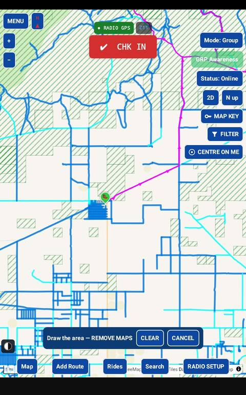

Remove maps by area. draw area with your finger

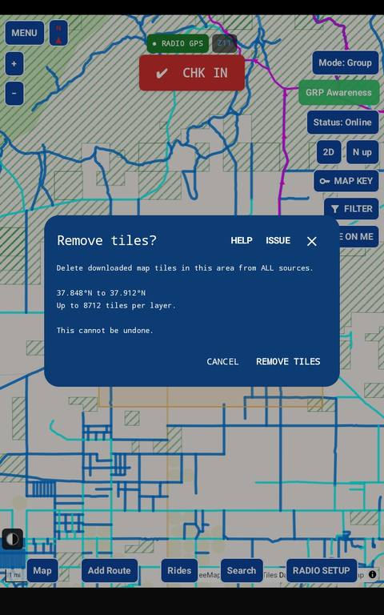

Select REMOVE TILES to proceed

Step by step

Map › **Remove maps by area**. Draw a rectangle round the area (**CLEAR** to draw again), confirm, and the maps inside it are removed.

**Remove maps for all tracks**

Overview

**What it does.** Deletes the maps that were downloaded along your tracks.

**How you use it.** Confirm, then run Download maps along tracks to download them again, current.

**What it means to you.** All the map data along the tracks you have ridden is brought up to date in two steps.

**When to use it.** When you want to refresh the maps for everywhere you have ridden.

Step by step

Map › **Remove maps for all tracks**. GroupTrack<sup>OG</sup> holds the queue, scans your tracks and shows how many tiles are on the tablet. **PROCEED**: the track coverage is removed and downloaded again; tracks reappear one at a time as each finishes, and your area maps stay visible the whole time. Downloads continue in the background, and resume if the app or tablet restarts.

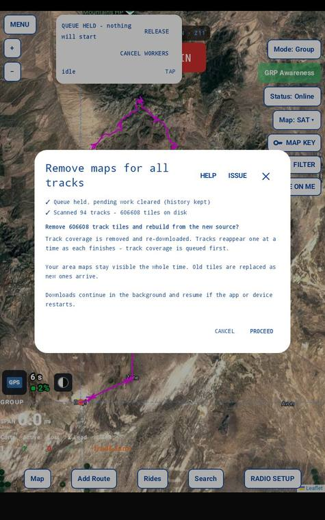

Confirmation of track tiles removal

**Resync tracks**

Overview

**What it does.** Makes your track list match the track files on this tablet.

**How you use it.** Run it if a track is missing from your list, or after copying track files on by hand.

**What it means to you.** Every ride you recorded is in your list and can be shared, exported or made into a route.

**When to use it.** A recorded ride is not in your list.

Step by step

**Only when GroupTrack<sup>OG</sup> support asks you to:** Map › **Resync tracks with their files** › **START**.

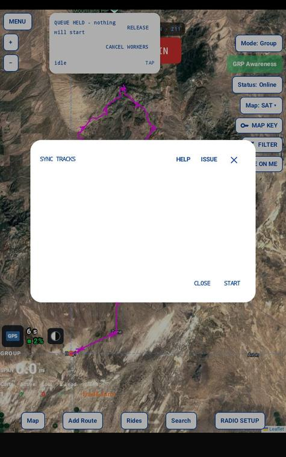

Resync tracks to all tracks in my tracks exist in db

**Delete imported trails by source (new in 2.7e)**

Overview

**What it does.** Removes the trails one import brought in, by the source name you gave when you imported them.

**How you use it.** Pick the import and confirm. Trails from state imports and your "Rider" trails are not listed — they cannot be removed here.

**What it means to you.** Try any trail map without worry: if it isn't useful, it comes back out completely, and nothing else is touched.

**When to use it.** A trail map you imported is wrong, out of date, or just clutter.

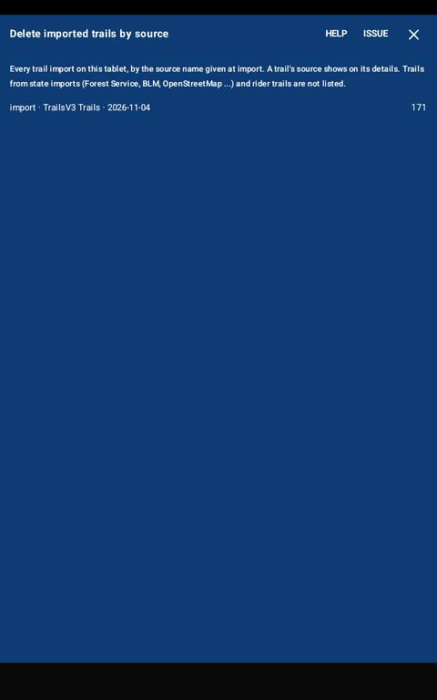

Delete imported (user-supplied) trails by source

Step by step

1. Map › SYNC OR REPAIR MAP FEATURES › **Delete imported trails by source**.
2. The list shows every import made with Import files (YES — trails), by the source name given and the date, with its trail count. Imports from before 4 November 2026 have no source name and show as one row.
3. Tap one; the panel asks **Delete N trails?** and names the source. **DELETE**.
4. A trail another source also has is kept and only loses this source. Trails from state imports and your "Rider" trails are never listed.

**Remove tracks and trails by area (new in 2.7e)**

Overview

**What it does.** Removes the tracks and trails lying wholly inside a box you draw.

**How you use it.** Draw the box. Tracks and "Rider" trails are ticked; state and imported trails are not — tick only what you mean to remove. Tap REMOVE. Waypoints, routes and rides are never removed.

**What it means to you.** A clean way to clear out an area — a test, an old import, tracks you no longer want — in one step.

**When to use it.** Cleaning up after a test or an old import that has no source name.

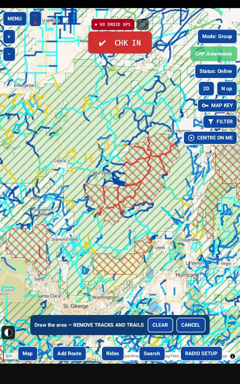

Remove tracks and trails by area

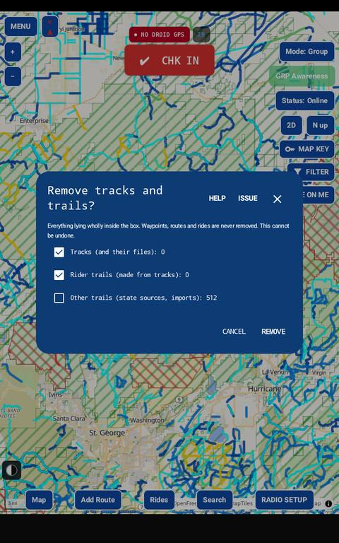

Tracks and trails selected for removal

Step by step

1. Map › SYNC OR REPAIR MAP FEATURES › **Remove tracks and trails by area**.
2. Draw a box; only what lies wholly inside it counts.
3. The panel lists, with their counts: **Tracks (and their files)** and **Rider trails (made from tracks)**, ticked; **Other trails (state sources, imports)**, not ticked. Tick only what you mean to remove.
4. **REMOVE**. The toast says how many tracks and trails went. Waypoints, routes and rides are never removed.

**Area Search Radius**

Overview

**What it does.** Sets how much of the map a search shows around the place it finds — a zoom level from Z12 (wider) to Z18 (closer); Z13 is standard.

**How you use it.** Slide to the level you want, tap SAVE. Across a tablet screen in portrait, about: Z12 7½ miles · Z13 3¾ miles (standard) · Z14 2 miles · Z15 1 mile · Z16 ½ mile · Z17 400 yards · Z18 200 yards. A phone shows about half that width.

**What it means to you.** A search drops you where you can see what you need around the place — the trail system, or just the trailhead.

**When to use it.** Searches show too much or too little around what you found.

Step by step

Map › **Area Search Radius**. Drag the slider: towards **Z12** shows a wider area, towards **Z18** closer (Z13 is standard). **SAVE**.

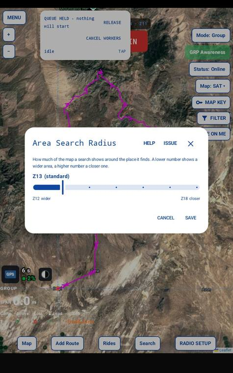

Area search radius

**Saved map recipes**

Overview

**How you use it.** Pick a day. RESTORE MY MAPS downloads those areas again (the download queue opens). SEND emails the recipe; another rider taps it once to get the same maps.

**When to use it.** "My tablet crashed and I lost my maps"; you removed an area by mistake; before a trip with someone who needs your maps.

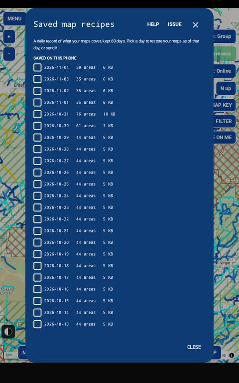

Saved map recipes

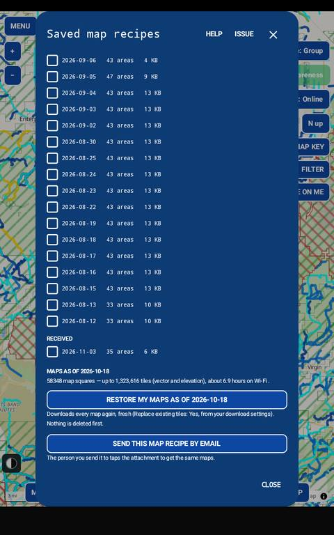

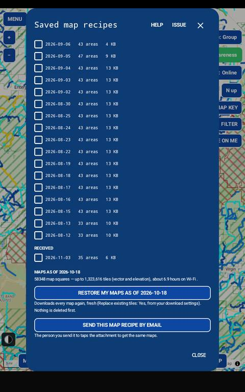

Select a day, then RESTORE MY MAPS or SEND

Step by step

1. Map › MAP RECOVERY › **Saved map recipes**.
2. Pick a day.
3. **RESTORE MY MAPS** — the screen closes and the download queue opens with that day's maps (map and ground shape).
4. **SEND** — shares the recipe as a small .json file. The rider who receives it taps the attachment once; GroupTrack<sup>OG</sup> opens it in his recipes (received), and RESTORE MY MAPS gets him the same maps.
5. A recipe saved by an AI route build opens AI route design with the filter it was built with; you can change it before building.

If the conversion to 2.7e was interrupted, Emergency download downloads your maps again as of the conversion date.

**Back up GroupTrack<sup>OG</sup> data (new in 2.7e)**

Overview

**What it does.** Saves everything needed to rebuild GroupTrack<sup>OG</sup> — your routes, tracks, waypoints and "Rider" trails as GPX files, and your map recipe — as five files in your **GroupTrack** folder on the tablet. GroupTrack<sup>OG</sup> does this by itself about every seven days; tapping this row is the immediate, on-demand version of that same scheduled weekly save.

**What it means to you.** A very important function. The newest set of files lets you clear and rebuild GroupTrack<sup>OG</sup> — after buying a new device, a crash, or clearing the app or its data by accident. Because it runs weekly on its own, a usable set is there whether or not you remember to tap it.

**When to use it.** Any time you want a fresh set immediately — above all before resetting or replacing your device, or after a ride you would not want to lose.

[figure not shown]

Step by step

Recovering

Good to know

**Export map features — routes, tracks, waypoints or rider trails (new in 2.8a)**

Overview

**What it does.** Writes the map features you choose — your routes, your tracks, your waypoints, your "Rider" trails — into GPX files in your Map Features folder. One file for each type you pick.

**How you use it.** Tick the types you want, or SELECT ALL. Tick *Send these features as an email* as well if you want to send them. EXPORT writes the files and closes the screen.

**What it means to you.** The files are saved on the tablet whether or not you send them — so they are there to send again, or to delete, whenever you want.

**When to use it.** Keeping a copy of your own features; moving to a new tablet; giving features to a riding partner.

Step by step

1. Map › EXPORT MAP FEATURES › **Export map features — routes, tracks, waypoints or rider trails**.
2. Tick the types you want. SELECT ALL ticks all four.
3. Tick *Send these features as an email* if you also want to send them.
4. EXPORT. One GPX file per type is written to your Map Features folder — `GroupTrack_ROUTES_<date>.gpx`, `GroupTrack_TRACKS_<date>.gpx`, `GroupTrack_WAYPOINTS_<date>.gpx`, `GroupTrack_RIDER_TRAILS_<date>.gpx` — and a message tells you how many were written.
5. If you ticked the email box, the share sheet opens with those files attached.

**Work with exported map features — email or delete a file you saved earlier (new in 2.8a)**

Overview

**What it does.** Lists the GPX files already in your Map Features folder, so you can send one by email or delete it.

**How you use it.** Tick one or more files, then EMAIL or DELETE.

**What it means to you.** Something you exported before can be sent again, or cleared out, without exporting it afresh.

**When to use it.** Sending a file to a partner who missed it; tidying up old exports.

Step by step

1. Map › EXPORT MAP FEATURES › **Work with exported map features**.
2. Tick the files you want.
3. EMAIL opens the share sheet with them attached; DELETE removes them from the folder.

**Export all routes — one GPX file (new in 2.7e)**

Overview

**What it does.** Writes every route you created into one GPX file and opens the share sheet.

**How you use it.** One tap; choose email, Drive or Files. Nothing on the tablet changes.

**What it means to you.** All your routes in one file — saved, or exchanged with your friends.

**When to use it.** Sharing your routes, or keeping a copy.

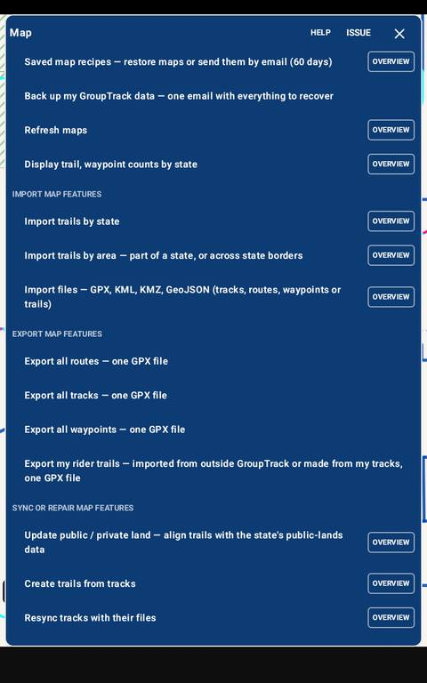

Map › EXPORT MAP FEATURES — the four exports

Step by step

1. Map › EXPORT MAP FEATURES › **Export all routes — one GPX file**.
2. The share sheet opens with `GroupTrack_ROUTES_<date>.gpx` — the type is in the name, so another tablet imports it as the right type.
3. Choose your email, Google Drive or Files.

**Export all tracks — one GPX file (new in 2.7e)**

Overview

**What it does.** Writes every track you recorded or imported into one GPX file and opens the share sheet.

**How you use it.** One tap; choose email, Drive or Files. Nothing on the tablet changes.

**What it means to you.** All your rides in one file — saved, or exchanged with your friends.

**When to use it.** Keeping a copy of your rides; giving them to a friend or another app.

Step by step

1. Map › EXPORT MAP FEATURES › **Export all tracks — one GPX file**.
2. The share sheet opens with `GroupTrack_TRACKS_<date>.gpx` — the type is in the name, so another tablet imports it as the right type.
3. Choose your email, Google Drive or Files.

**Export all waypoints — one GPX file (new in 2.7e)**

Overview

**What it does.** Writes every waypoint into one GPX file and opens the share sheet.

**How you use it.** One tap; choose email, Drive or Files. Nothing on the tablet changes.

**What it means to you.** All your trailheads and places in one file — saved, or exchanged with your friends.

**When to use it.** Sharing your trailheads, or keeping a copy.

Step by step

1. Map › EXPORT MAP FEATURES › **Export all waypoints — one GPX file**.
2. The share sheet opens with `GroupTrack_WAYPOINTS_<date>.gpx` — the type is in the name, so another tablet imports it as the right type.
3. Choose your email, Google Drive or Files.

**Export my rider trails — one GPX file (new in 2.7e)**

Overview

**What it does.** Writes your "Rider" trails into one GPX file and opens the share sheet: every new trail created by a track you have ridden, and the trails you imported from outside GroupTrack<sup>OG</sup>. State trails are not included — everyone can import those.

**How you use it.** One tap; choose email, Drive or Files. On another tablet, open it with Import files — it comes back as trails.

**What it means to you.** The trails only you have, in one file — saved, or exchanged with your friends.

**When to use it.** Moving to a new device; giving a riding partner your trails.

Step by step

1. Map › EXPORT MAP FEATURES › **Export my rider trails — one GPX file**.
2. The share sheet opens with `GroupTrack_RIDER_TRAILS_<date>.gpx` — the type is in the name, so another tablet imports it as the right type.
3. Choose your email, Google Drive or Files.

**Emergency download — maps as of the conversion date (2.7e)**

Overview

**What it does.** Downloads every map you had when GroupTrack<sup>OG</sup> moved to the new map in version 2.7e (earlier versions used satellite and topo maps), from the record it kept on the conversion date.

**How you use it.** Tap START; the queue does the rest.

**What it means to you.** Every map you had before the update comes back in the new format — none is lost.